# Modelo de Clasificación Binaria para la Predicción de Bancarrota Empresarial a partir de Estados Financieros: Dataset Taiwan Economic Journal

**Continuous Net Profit Growth Rate**

| Variable | N | Media | DS | Curtosis | Mediana | Mínimo | Máximo | Q1 | Q3 | IQR |
| --- | --- | --- | --- | --- | --- | --- | --- | --- | --- | --- |
| Continuous Net Profit Growth Rate | 5456 | 0.2176671 | 0.0112233 | 4354.93 | 0.2175982 | 0 | 1 | 0.2175799 | 0.2176219 | 4.2e-05 |

Continuous Net Profit Growth Rate

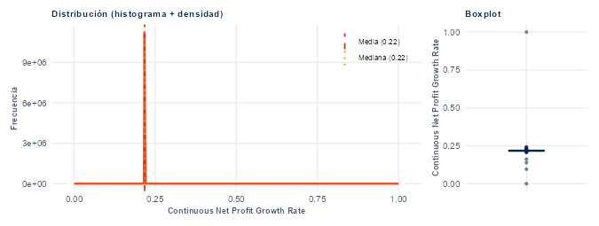

El histograma de Continuous Net Profit Growth Rate muestra un marcado sesgo a la derecha (asimetría positiva), con una media de 21.77% y una mediana de 21.76%. La curtosis observada de 4358.92 indica una concentración notable de observaciones alrededor de la zona central, acompañada por la presencia de valores atípicos en las colas. Esta morfología sugiere una alta homogeneidad en el grueso de las empresas analizadas, pero con comportamientos extremos puntuales a monitorear en la etapa de preprocesamiento.

**Total Asset Growth Rate**

| Variable | N | Media | DS | Curtosis | Mediana | Mínimo | Máximo | Q1 | Q3 | IQR |
| --- | --- | --- | --- | --- | --- | --- | --- | --- | --- | --- |
| Total Asset Growth Rate | 5456 | 5528156378 | 2895923411 | -0.3931113 | 6.42e+09 | 0 | 9.98e+09 | 4.88e+09 | 7.4e+09 | 2.52e+09 |

Total Asset Growth Rate

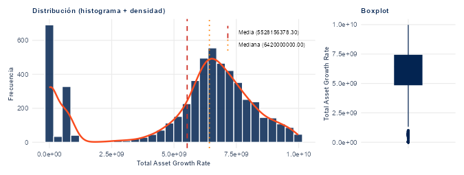

**Net Value Growth Rate**

| Variable | N | Media | DS | Curtosis | Mediana | Mínimo | Máximo | Q1 | Q3 | IQR |
| --- | --- | --- | --- | --- | --- | --- | --- | --- | --- | --- |
| Net Value Growth Rate | 5456 | 1957478 | 127624057 | 5231.873 | 0.0004621 | 0 | 9.33e+09 | 0.0004411 | 0.0004994 | 5.83e-05 |

Net Value Growth Rate

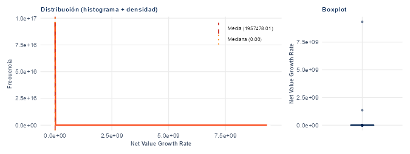

El histograma de Net Value Growth Rate muestra un marcado sesgo a la derecha (asimetría positiva), con una media de 195747800.66% y una mediana de 0.05%. La curtosis observada de 5236.67 indica una concentración notable de observaciones alrededor de la zona central, acompañada por la presencia de valores atípicos en las colas. Esta morfología sugiere una alta homogeneidad en el grueso de las empresas analizadas, pero con comportamientos extremos puntuales a monitorear en la etapa de preprocesamiento.

**Total Asset Return Growth Rate Ratio**

| Variable | N | Media | DS | Curtosis | Mediana | Mínimo | Máximo | Q1 | Q3 | IQR |
| --- | --- | --- | --- | --- | --- | --- | --- | --- | --- | --- |
| Total Asset Return Growth Rate Ratio | 5456 | 0.2641387 | 0.0040617 | 3338.909 | 0.2640542 | 0 | 0.3586288 | 0.2637657 | 0.2643922 | 0.0006265 |

Total Asset Return Growth Rate Ratio

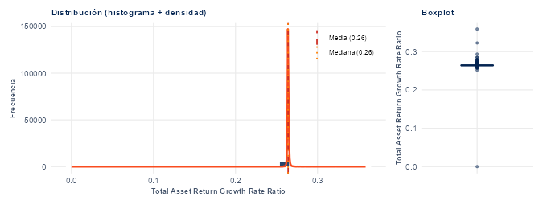

El histograma de Total Asset Return Growth Rate Ratio muestra un marcado sesgo a la izquierda (asimetría negativa), con una media de 26.41% y una mediana de 26.41%. La curtosis observada de 3341.97 indica una concentración notable de observaciones alrededor de la zona central, acompañada por la presencia de valores atípicos en las colas. Esta morfología sugiere una alta homogeneidad en el grueso de las empresas analizadas, pero con comportamientos extremos puntuales a monitorear en la etapa de preprocesamiento.

**Cash Reinvestment %**

| Variable | N | Media | DS | Curtosis | Mediana | Mínimo | Máximo | Q1 | Q3 | IQR |
| --- | --- | --- | --- | --- | --- | --- | --- | --- | --- | --- |
| Cash Reinvestment % | 5456 | 0.3796161 | 0.0192963 | 72.40594 | 0.380323 | 0.025828 | 0.7599475 | 0.3747345 | 0.3868359 | 0.0121014 |

Cash Reinvestment %

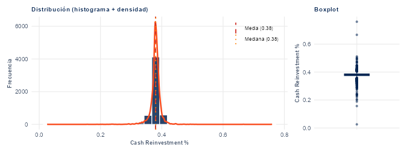

El histograma de Cash Reinvestment % muestra un marcado sesgo a la izquierda (asimetría negativa), con una media de 37.96% y una mediana de 38.03%. La curtosis observada de 72.47 indica una concentración notable de observaciones alrededor de la zona central, acompañada por la presencia de valores atípicos en las colas. Esta morfología sugiere una alta homogeneidad en el grueso de las empresas analizadas, pero con comportamientos extremos puntuales a monitorear en la etapa de preprocesamiento.

**Current Ratio**

| Variable | N | Media | DS | Curtosis | Mediana | Mínimo | Máximo | Q1 | Q3 | IQR |
| --- | --- | --- | --- | --- | --- | --- | --- | --- | --- | --- |
| Current Ratio | 5456 | 504032.3 | 37230212 | 5451 | 0.010561 | 0 | 2.75e+09 | 0.0075312 | 0.016178 | 0.0086468 |

Current Ratio

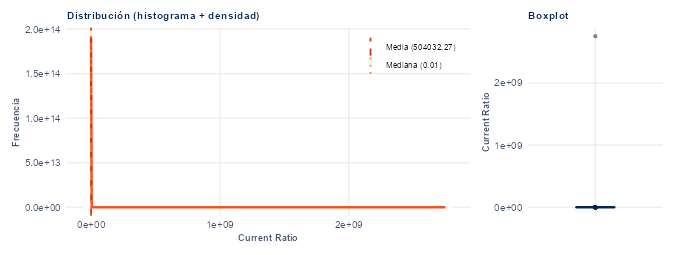

El histograma de Current Ratio muestra un marcado sesgo a la derecha (asimetría positiva), con una media de 504032.2733 ratio y una mediana de 0.0106 ratio. La curtosis observada de 5456.00 indica una concentración notable de observaciones alrededor de la zona central, acompañada por la presencia de valores atípicos en las colas. Esta morfología sugiere una alta homogeneidad en el grueso de las empresas analizadas, pero con comportamientos extremos puntuales a monitorear en la etapa de preprocesamiento.

**Quick Ratio**

| Variable | N | Media | DS | Curtosis | Mediana | Mínimo | Máximo | Q1 | Q3 | IQR |
| --- | --- | --- | --- | --- | --- | --- | --- | --- | --- | --- |
| Quick Ratio | 5456 | 9508798 | 264185268 | 937.6647 | 0.0073941 | 0 | 9.23e+09 | 0.0047114 | 0.012217 | 0.0075056 |

Quick Ratio

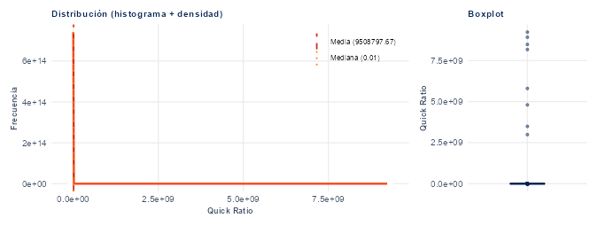

El histograma de Quick Ratio muestra un marcado sesgo a la derecha (asimetría positiva), con una media de 9508797.6651 ratio y una mediana de 0.0074 ratio. La curtosis observada de 938.53 indica una concentración notable de observaciones alrededor de la zona central, acompañada por la presencia de valores atípicos en las colas. Esta morfología sugiere una alta homogeneidad en el grueso de las empresas analizadas, pero con comportamientos extremos puntuales a monitorear en la etapa de preprocesamiento.

**Interest Expense Ratio**

| Variable | N | Media | DS | Curtosis | Mediana | Mínimo | Máximo | Q1 | Q3 | IQR |
| --- | --- | --- | --- | --- | --- | --- | --- | --- | --- | --- |
| Interest Expense Ratio | 5456 | 0.6309552 | 0.0112163 | 1973.017 | 0.6306999 | 0 | 0.8977874 | 0.6306123 | 0.6311413 | 0.000529 |

Interest Expense Ratio

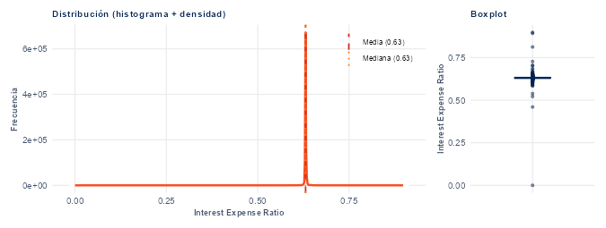

El histograma de Interest Expense Ratio muestra un marcado sesgo a la izquierda (asimetría negativa), con una media de 63.10% y una mediana de 63.07%. La curtosis observada de 1974.83 indica una concentración notable de observaciones alrededor de la zona central, acompañada por la presencia de valores atípicos en las colas. Esta morfología sugiere una alta homogeneidad en el grueso de las empresas analizadas, pero con comportamientos extremos puntuales a monitorear en la etapa de preprocesamiento.

**Total debt/Total net worth**

| Variable | N | Media | DS | Curtosis | Mediana | Mínimo | Máximo | Q1 | Q3 | IQR |
| --- | --- | --- | --- | --- | --- | --- | --- | --- | --- | --- |
| Total debt/Total net worth | 5456 | 5519611 | 188258113 | 1876.564 | 0.0055285 | 0 | 9.94e+09 | 0.00302 | 0.0093095 | 0.0062895 |

Total debt/Total net worth

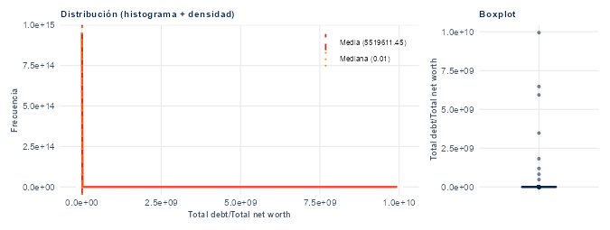

El histograma de Total debt/Total net worth muestra un marcado sesgo a la derecha (asimetría positiva), con una media de 5519611.4450 ratio y una mediana de 0.0055 ratio. La curtosis observada de 1878.29 indica una concentración notable de observaciones alrededor de la zona central, acompañada por la presencia de valores atípicos en las colas. Esta morfología sugiere una alta homogeneidad en el grueso de las empresas analizadas, pero con comportamientos extremos puntuales a monitorear en la etapa de preprocesamiento.

**Debt ratio %**

| Variable | N | Media | DS | Curtosis | Mediana | Mínimo | Máximo | Q1 | Q3 | IQR |
| --- | --- | --- | --- | --- | --- | --- | --- | --- | --- | --- |
| Debt ratio % | 5456 | 0.1134512 | 0.0543518 | 13.02561 | 0.1111649 | 0 | 1 | 0.0730417 | 0.1490084 | 0.0759667 |

Debt ratio %

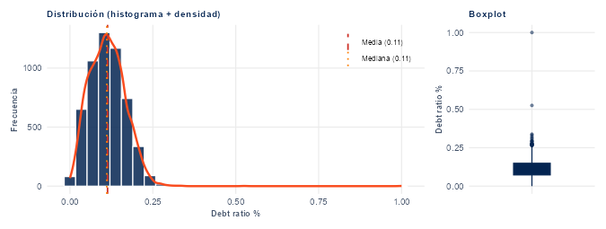

El histograma de Debt ratio % muestra un marcado sesgo a la derecha (asimetría positiva), con una media de 11.35% y una mediana de 11.12%. La curtosis observada de 13.04 indica una concentración notable de observaciones alrededor de la zona central, acompañada por la presencia de valores atípicos en las colas. Esta morfología sugiere una alta homogeneidad en el grueso de las empresas analizadas, pero con comportamientos extremos puntuales a monitorear en la etapa de preprocesamiento.

**Net worth/Assets**

| Variable | N | Media | DS | Curtosis | Mediana | Mínimo | Máximo | Q1 | Q3 | IQR |
| --- | --- | --- | --- | --- | --- | --- | --- | --- | --- | --- |
| Net worth/Assets | 5456 | 0.8865488 | 0.0543518 | 13.02561 | 0.8888351 | 0 | 1 | 0.8509916 | 0.9269583 | 0.0759667 |

Net worth/Assets

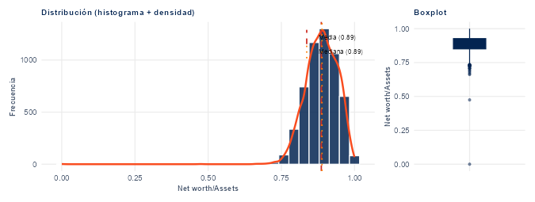

El histograma de Net worth/Assets muestra un marcado sesgo a la izquierda (asimetría negativa), con una media de 88.65% y una mediana de 88.88%. La curtosis observada de 13.04 indica una concentración notable de observaciones alrededor de la zona central, acompañada por la presencia de valores atípicos en las colas. Esta morfología sugiere una alta homogeneidad en el grueso de las empresas analizadas, pero con comportamientos extremos puntuales a monitorear en la etapa de preprocesamiento.

**Long-term fund suitability ratio (A)**

| Variable | N | Media | DS | Curtosis | Mediana | Mínimo | Máximo | Q1 | Q3 | IQR |
| --- | --- | --- | --- | --- | --- | --- | --- | --- | --- | --- |
| Long-term fund suitability ratio (A) | 5456 | 0.0085466 | 0.0260366 | 847.2348 | 0.0056491 | 0 | 1 | 0.0052352 | 0.0068332 | 0.001598 |

Long-term fund suitability ratio (A)

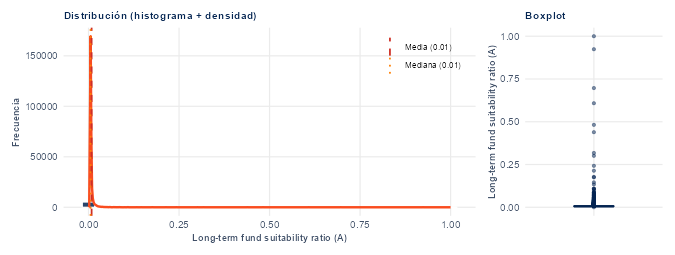

El histograma de Long-term fund suitability ratio (A) muestra un marcado sesgo a la derecha (asimetría positiva), con una media de 0.0085 ratio y una mediana de 0.0056 ratio. La curtosis observada de 848.01 indica una concentración notable de observaciones alrededor de la zona central, acompañada por la presencia de valores atípicos en las colas. Esta morfología sugiere una alta homogeneidad en el grueso de las empresas analizadas, pero con comportamientos extremos puntuales a monitorear en la etapa de preprocesamiento.

**Borrowing dependency**

| Variable | N | Media | DS | Curtosis | Mediana | Mínimo | Máximo | Q1 | Q3 | IQR |
| --- | --- | --- | --- | --- | --- | --- | --- | --- | --- | --- |
| Borrowing dependency | 5456 | 0.3746208 | 0.0160948 | 852.377 | 0.3726294 | 0 | 1 | 0.3701815 | 0.3762461 | 0.0060646 |

Borrowing dependency

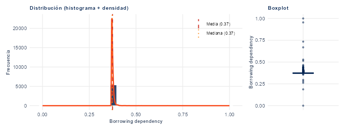

El histograma de Borrowing dependency muestra un marcado sesgo a la derecha (asimetría positiva), con una media de 0.3746 ratio y una mediana de 0.3726 ratio. La curtosis observada de 853.16 indica una concentración notable de observaciones alrededor de la zona central, acompañada por la presencia de valores atípicos en las colas. Esta morfología sugiere una alta homogeneidad en el grueso de las empresas analizadas, pero con comportamientos extremos puntuales a monitorear en la etapa de preprocesamiento.

**Contingent liabilities/Net worth**

| Variable | N | Media | DS | Curtosis | Mediana | Mínimo | Máximo | Q1 | Q3 | IQR |
| --- | --- | --- | --- | --- | --- | --- | --- | --- | --- | --- |
| Contingent liabilities/Net worth | 5456 | 0.0060071 | 0.0136129 | 5209.511 | 0.0053658 | 0 | 1 | 0.0053658 | 0.0057663 | 0.0004005 |

Contingent liabilities/Net worth

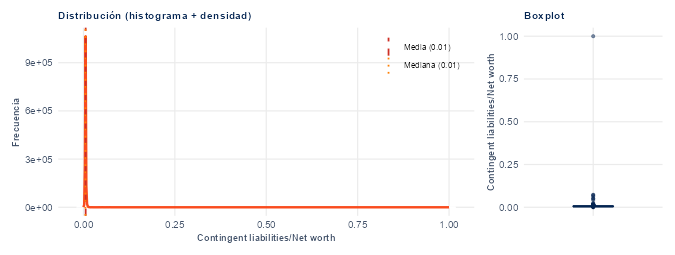

El histograma de Contingent liabilities/Net worth muestra un marcado sesgo a la derecha (asimetría positiva), con una media de 0.0060 ratio y una mediana de 0.0054 ratio. La curtosis observada de 5214.29 indica una concentración notable de observaciones alrededor de la zona central, acompañada por la presencia de valores atípicos en las colas. Esta morfología sugiere una alta homogeneidad en el grueso de las empresas analizadas, pero con comportamientos extremos puntuales a monitorear en la etapa de preprocesamiento.

**Operating profit/Paid-in capital**

| Variable | N | Media | DS | Curtosis | Mediana | Mínimo | Máximo | Q1 | Q3 | IQR |
| --- | --- | --- | --- | --- | --- | --- | --- | --- | --- | --- |
| Operating profit/Paid-in capital | 5456 | 0.108814 | 0.0258905 | 94.44064 | 0.1041779 | 0 | 0.7354292 | 0.0960864 | 0.1157726 | 0.0196863 |

Operating profit/Paid-in capital

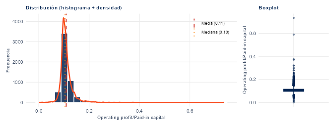

El histograma de Operating profit/Paid-in capital muestra un marcado sesgo a la derecha (asimetría positiva), con una media de 10.88% y una mediana de 10.42%. La curtosis observada de 94.53 indica una concentración notable de observaciones alrededor de la zona central, acompañada por la presencia de valores atípicos en las colas. Esta morfología sugiere una alta homogeneidad en el grueso de las empresas analizadas, pero con comportamientos extremos puntuales a monitorear en la etapa de preprocesamiento.

**Net profit before tax/Paid-in capital**

| Variable | N | Media | DS | Curtosis | Mediana | Mínimo | Máximo | Q1 | Q3 | IQR |
| --- | --- | --- | --- | --- | --- | --- | --- | --- | --- | --- |
| Net profit before tax/Paid-in capital | 5456 | 0.1825124 | 0.0291451 | 69.87528 | 0.1785725 | 0.0524395 | 0.7921047 | 0.1694442 | 0.1914675 | 0.0220232 |

Net profit before tax/Paid-in capital

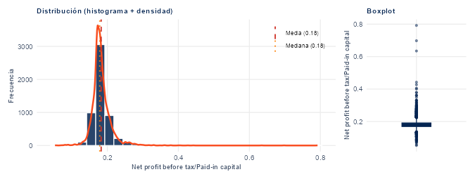

El histograma de Net profit before tax/Paid-in capital muestra un marcado sesgo a la derecha (asimetría positiva), con una media de 18.25% y una mediana de 17.86%. La curtosis observada de 69.94 indica una concentración notable de observaciones alrededor de la zona central, acompañada por la presencia de valores atípicos en las colas. Esta morfología sugiere una alta homogeneidad en el grueso de las empresas analizadas, pero con comportamientos extremos puntuales a monitorear en la etapa de preprocesamiento.

**Inventory and accounts receivable/Net value**

| Variable | N | Media | DS | Curtosis | Mediana | Mínimo | Máximo | Q1 | Q3 | IQR |
| --- | --- | --- | --- | --- | --- | --- | --- | --- | --- | --- |
| Inventory and accounts receivable/Net value | 5456 | 0.4024175 | 0.0115723 | 388.3899 | 0.4001156 | 0 | 0.7074447 | 0.3974104 | 0.4044905 | 0.0070801 |

Inventory and accounts receivable/Net value

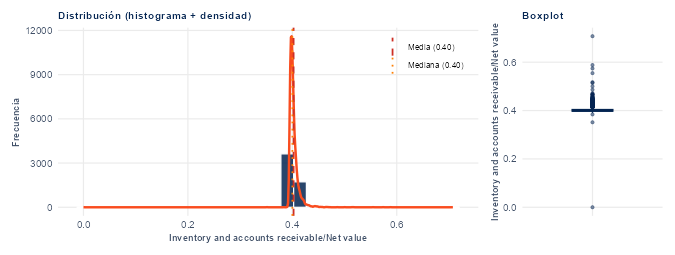

**Total Asset Turnover**

| Variable | N | Media | DS | Curtosis | Mediana | Mínimo | Máximo | Q1 | Q3 | IQR |
| --- | --- | --- | --- | --- | --- | --- | --- | --- | --- | --- |
| Total Asset Turnover | 5456 | 0.1418012 | 0.1017072 | 9.620414 | 0.1184408 | 0 | 1 | 0.0764618 | 0.1769115 | 0.1004498 |

Total Asset Turnover

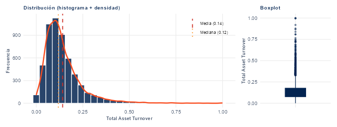

El histograma de Total Asset Turnover muestra un marcado sesgo a la derecha (asimetría positiva), con una media de 0.1418 ratio y una mediana de 0.1184 ratio. La curtosis observada de 9.63 indica una concentración notable de observaciones alrededor de la zona central, acompañada por la presencia de valores atípicos en las colas. Esta morfología sugiere una alta homogeneidad en el grueso de las empresas analizadas, pero con comportamientos extremos puntuales a monitorear en la etapa de preprocesamiento.

**Accounts Receivable Turnover**

| Variable | N | Media | DS | Curtosis | Mediana | Mínimo | Máximo | Q1 | Q3 | IQR |
| --- | --- | --- | --- | --- | --- | --- | --- | --- | --- | --- |
| Accounts Receivable Turnover | 5456 | 13401576 | 281589298 | 737.2422 | 0.0009678 | 0 | 9.74e+09 | 0.0007081 | 0.0014608 | 0.0007527 |

Accounts Receivable Turnover

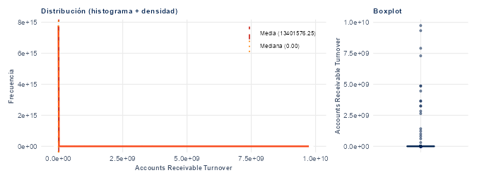

El histograma de Accounts Receivable Turnover muestra un marcado sesgo a la derecha (asimetría positiva), con una media de 13401576.2485 ratio y una mediana de 0.0010 ratio. La curtosis observada de 737.92 indica una concentración notable de observaciones alrededor de la zona central, acompañada por la presencia de valores atípicos en las colas. Esta morfología sugiere una alta homogeneidad en el grueso de las empresas analizadas, pero con comportamientos extremos puntuales a monitorear en la etapa de preprocesamiento.

**Average Collection Days**

| Variable | N | Media | DS | Curtosis | Mediana | Mínimo | Máximo | Q1 | Q3 | IQR |
| --- | --- | --- | --- | --- | --- | --- | --- | --- | --- | --- |
| Average Collection Days | 5456 | 9438050 | 249403309 | 952.6427 | 0.0065704 | 0 | 8.8e+09 | 0.0043701 | 0.0089789 | 0.0046088 |

Average Collection Days

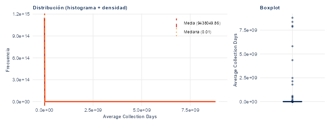

El histograma de Average Collection Days muestra un marcado sesgo a la derecha (asimetría positiva), con una media de 9438049.8612 días y una mediana de 0.0066 días. La curtosis observada de 953.52 indica una concentración notable de observaciones alrededor de la zona central, acompañada por la presencia de valores atípicos en las colas. Esta morfología sugiere una alta homogeneidad en el grueso de las empresas analizadas, pero con comportamientos extremos puntuales a monitorear en la etapa de preprocesamiento.

**Inventory Turnover Rate (times)**

| Variable | N | Media | DS | Curtosis | Mediana | Mínimo | Máximo | Q1 | Q3 | IQR |
| --- | --- | --- | --- | --- | --- | --- | --- | --- | --- | --- |
| Inventory Turnover Rate (times) | 5456 | 2125743768 | 3235358638 | -0.2867894 | 0.0006855 | 0 | 9.99e+09 | 0.0001706 | 4.59e+09 | 4.59e+09 |

Inventory Turnover Rate (times)

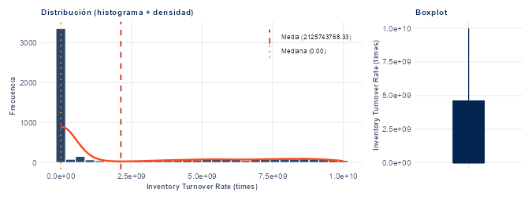

**Fixed Assets Turnover Frequency**

| Variable | N | Media | DS | Curtosis | Mediana | Mínimo | Máximo | Q1 | Q3 | IQR |
| --- | --- | --- | --- | --- | --- | --- | --- | --- | --- | --- |
| Fixed Assets Turnover Frequency | 5456 | 1020131745 | 2481016089 | 3.972441 | 0.0005878 | 0 | 9.99e+09 | 0.00023 | 0.0038005 | 0.0035705 |

Fixed Assets Turnover Frequency

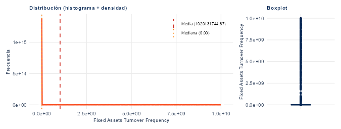

El histograma de Fixed Assets Turnover Frequency muestra un marcado sesgo a la derecha (asimetría positiva), con una media de 1020131744.8699 ratio y una mediana de 0.0006 ratio. La curtosis observada de 3.98 indica una concentración notable de observaciones alrededor de la zona central, acompañada por la presencia de valores atípicos en las colas. Esta morfología sugiere una alta homogeneidad en el grueso de las empresas analizadas, pero con comportamientos extremos puntuales a monitorear en la etapa de preprocesamiento.

**Net Worth Turnover Rate (times)**

| Variable | N | Media | DS | Curtosis | Mediana | Mínimo | Máximo | Q1 | Q3 | IQR |
| --- | --- | --- | --- | --- | --- | --- | --- | --- | --- | --- |
| Net Worth Turnover Rate (times) | 5456 | 0.0386093 | 0.0363067 | 153.7349 | 0.0295161 | 0 | 1 | 0.0219355 | 0.0429435 | 0.0210081 |

Net Worth Turnover Rate (times)

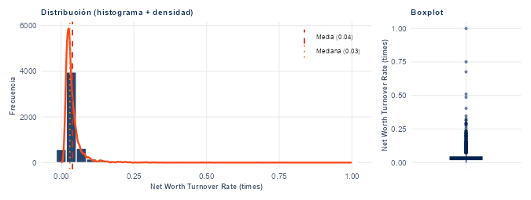

El histograma de Net Worth Turnover Rate (times) muestra un marcado sesgo a la derecha (asimetría positiva), con una media de 0.0386 ratio y una mediana de 0.0295 ratio. La curtosis observada de 153.88 indica una concentración notable de observaciones alrededor de la zona central, acompañada por la presencia de valores atípicos en las colas. Esta morfología sugiere una alta homogeneidad en el grueso de las empresas analizadas, pero con comportamientos extremos puntuales a monitorear en la etapa de preprocesamiento.

**Revenue per person**

| Variable | N | Media | DS | Curtosis | Mediana | Mínimo | Máximo | Q1 | Q3 | IQR |
| --- | --- | --- | --- | --- | --- | --- | --- | --- | --- | --- |
| Revenue per person | 5456 | 2906892 | 152746021 | 2854.151 | 0.0185509 | 0 | 8.81e+09 | 0.0103344 | 0.0358496 | 0.0255152 |

Revenue per person

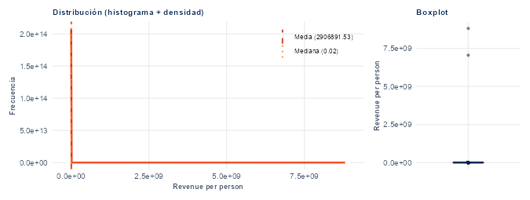

El histograma de Revenue per person muestra un marcado sesgo a la derecha (asimetría positiva), con una media de 2906891.5313 Yuan ¥/persona y una mediana de 0.0186 Yuan ¥/persona. La curtosis observada de 2856.77 indica una concentración notable de observaciones alrededor de la zona central, acompañada por la presencia de valores atípicos en las colas. Esta morfología sugiere una alta homogeneidad en el grueso de las empresas analizadas, pero con comportamientos extremos puntuales a monitorear en la etapa de preprocesamiento.

**Operating profit per person**

| Variable | N | Media | DS | Curtosis | Mediana | Mínimo | Máximo | Q1 | Q3 | IQR |
| --- | --- | --- | --- | --- | --- | --- | --- | --- | --- | --- |
| Operating profit per person | 5456 | 0.4007497 | 0.0325458 | 119.8843 | 0.3958753 | 0.0509147 | 1 | 0.392438 | 0.4018651 | 0.0094271 |

Operating profit per person

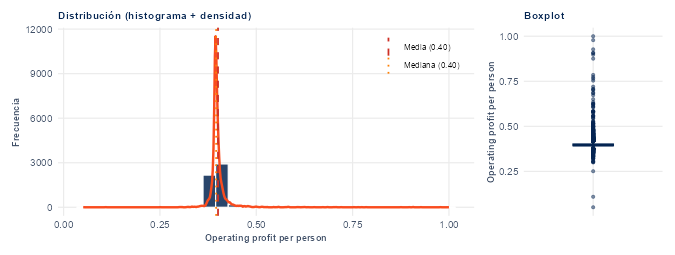

El histograma de Operating profit per person muestra un marcado sesgo a la derecha (asimetría positiva), con una media de 0.4007 Yuan ¥/persona y una mediana de 0.3959 Yuan ¥/persona. La curtosis observada de 120.00 indica una concentración notable de observaciones alrededor de la zona central, acompañada por la presencia de valores atípicos en las colas. Esta morfología sugiere una alta homogeneidad en el grueso de las empresas analizadas, pero con comportamientos extremos puntuales a monitorear en la etapa de preprocesamiento.

**Allocation rate per person**

| Variable | N | Media | DS | Curtosis | Mediana | Mínimo | Máximo | Q1 | Q3 | IQR |
| --- | --- | --- | --- | --- | --- | --- | --- | --- | --- | --- |
| Allocation rate per person | 5456 | 11242669 | 301592952 | 775.2381 | 0.0078763 | 0 | 9.57e+09 | 0.0040956 | 0.015237 | 0.0111413 |

Allocation rate per person

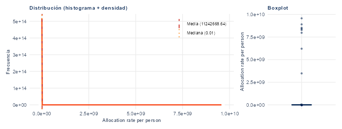

El histograma de Allocation rate per person muestra un marcado sesgo a la derecha (asimetría positiva), con una media de 11242668.6376 Yuan ¥/persona y una mediana de 0.0079 Yuan ¥/persona. La curtosis observada de 775.95 indica una concentración notable de observaciones alrededor de la zona central, acompañada por la presencia de valores atípicos en las colas. Esta morfología sugiere una alta homogeneidad en el grueso de las empresas analizadas, pero con comportamientos extremos puntuales a monitorear en la etapa de preprocesamiento.

**Working Capital to Total Assets**

| Variable | N | Media | DS | Curtosis | Mediana | Mínimo | Máximo | Q1 | Q3 | IQR |
| --- | --- | --- | --- | --- | --- | --- | --- | --- | --- | --- |
| Working Capital to Total Assets | 5456 | 0.8136989 | 0.0595694 | 6.612482 | 0.8093331 | 0 | 1 | 0.7738915 | 0.8500086 | 0.0761171 |

Working Capital to Total Assets

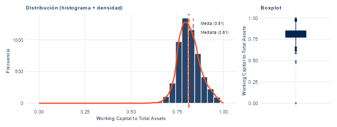

El histograma de Working Capital to Total Assets muestra una distribución relativamente simétrica, con una media de 0.8137 ratio y una mediana de 0.8093 ratio. La curtosis observada de 6.62 indica una concentración notable de observaciones alrededor de la zona central, acompañada por la presencia de valores atípicos en las colas. Esta morfología sugiere una alta homogeneidad en el grueso de las empresas analizadas, pero con comportamientos extremos puntuales a monitorear en la etapa de preprocesamiento.

**Quick Assets/Total Assets**

| Variable | N | Media | DS | Curtosis | Mediana | Mínimo | Máximo | Q1 | Q3 | IQR |
| --- | --- | --- | --- | --- | --- | --- | --- | --- | --- | --- |
| Quick Assets/Total Assets | 5456 | 0.3997391 | 0.202765 | -0.5576441 | 0.3850575 | 0 | 1 | 0.2406796 | 0.5403817 | 0.299702 |

Quick Assets/Total Assets

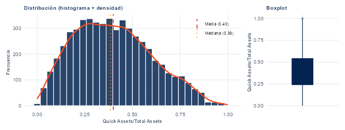

**Current Assets/Total Assets**

| Variable | N | Media | DS | Curtosis | Mediana | Mínimo | Máximo | Q1 | Q3 | IQR |
| --- | --- | --- | --- | --- | --- | --- | --- | --- | --- | --- |
| Current Assets/Total Assets | 5456 | 0.5210894 | 0.2179506 | -0.8036477 | 0.5118295 | 0 | 1 | 0.3504494 | 0.6866149 | 0.3361655 |

Current Assets/Total Assets

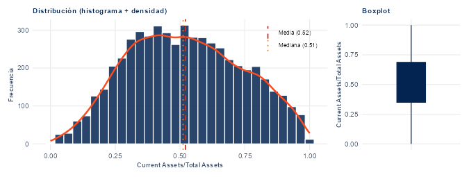

**Cash/Total Assets**

| Variable | N | Media | DS | Curtosis | Mediana | Mínimo | Máximo | Q1 | Q3 | IQR |
| --- | --- | --- | --- | --- | --- | --- | --- | --- | --- | --- |
| Cash/Total Assets | 5456 | 0.1231 | 0.1396816 | 5.986914 | 0.0733845 | 0.0001842 | 1 | 0.0325943 | 0.1596483 | 0.127054 |

Cash/Total Assets

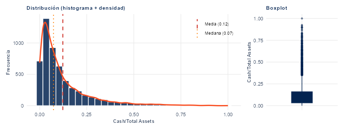

El histograma de Cash/Total Assets muestra un marcado sesgo a la derecha (asimetría positiva), con una media de 0.1231 ratio y una mediana de 0.0734 ratio. La curtosis observada de 5.99 indica una concentración notable de observaciones alrededor de la zona central, acompañada por la presencia de valores atípicos en las colas. Esta morfología sugiere una alta homogeneidad en el grueso de las empresas analizadas, pero con comportamientos extremos puntuales a monitorear en la etapa de preprocesamiento.

**Quick Assets/Current Liability**

| Variable | N | Media | DS | Curtosis | Mediana | Mínimo | Máximo | Q1 | Q3 | IQR |
| --- | --- | --- | --- | --- | --- | --- | --- | --- | --- | --- |
| Quick Assets/Current Liability | 5456 | 4490469 | 191856951 | 1843.416 | 0.0078965 | 0 | 8.82e+09 | 0.0052336 | 0.0128243 | 0.0075907 |

Quick Assets/Current Liability

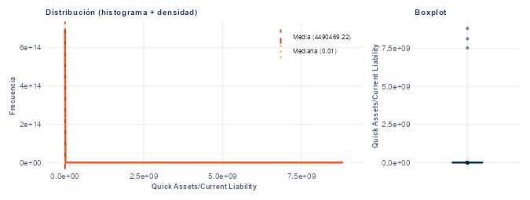

El histograma de Quick Assets/Current Liability muestra un marcado sesgo a la derecha (asimetría positiva), con una media de 4490469.2200 ratio y una mediana de 0.0079 ratio. La curtosis observada de 1845.11 indica una concentración notable de observaciones alrededor de la zona central, acompañada por la presencia de valores atípicos en las colas. Esta morfología sugiere una alta homogeneidad en el grueso de las empresas analizadas, pero con comportamientos extremos puntuales a monitorear en la etapa de preprocesamiento.

**Cash/Current Liability**

| Variable | N | Media | DS | Curtosis | Mediana | Mínimo | Máximo | Q1 | Q3 | IQR |
| --- | --- | --- | --- | --- | --- | --- | --- | --- | --- | --- |
| Cash/Current Liability | 5456 | 39106488 | 522711251 | 217.3877 | 0.0048368 | 0.0001009 | 9.65e+09 | 0.0019133 | 0.0126707 | 0.0107574 |

Cash/Current Liability

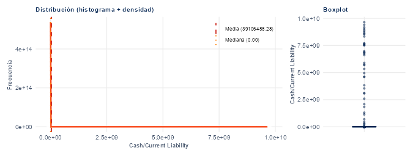

El histograma de Cash/Current Liability muestra un marcado sesgo a la derecha (asimetría positiva), con una media de 39106488.2830 ratio y una mediana de 0.0048 ratio. La curtosis observada de 217.59 indica una concentración notable de observaciones alrededor de la zona central, acompañada por la presencia de valores atípicos en las colas. Esta morfología sugiere una alta homogeneidad en el grueso de las empresas analizadas, pero con comportamientos extremos puntuales a monitorear en la etapa de preprocesamiento.

**Current Liability to Assets**

| Variable | N | Media | DS | Curtosis | Mediana | Mínimo | Máximo | Q1 | Q3 | IQR |
| --- | --- | --- | --- | --- | --- | --- | --- | --- | --- | --- |
| Current Liability to Assets | 5456 | 0.0907872 | 0.0508261 | 18.89208 | 0.0823457 | 0 | 1 | 0.0534706 | 0.1188467 | 0.0653761 |

Current Liability to Assets

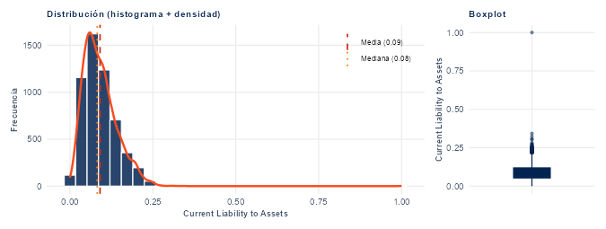

El histograma de Current Liability to Assets muestra un marcado sesgo a la derecha (asimetría positiva), con una media de 9.08% y una mediana de 8.23%. La curtosis observada de 18.91 indica una concentración notable de observaciones alrededor de la zona central, acompañada por la presencia de valores atípicos en las colas. Esta morfología sugiere una alta homogeneidad en el grueso de las empresas analizadas, pero con comportamientos extremos puntuales a monitorear en la etapa de preprocesamiento.

**Operating Funds to Liability**

| Variable | N | Media | DS | Curtosis | Mediana | Mínimo | Máximo | Q1 | Q3 | IQR |
| --- | --- | --- | --- | --- | --- | --- | --- | --- | --- | --- |
| Operating Funds to Liability | 5456 | 0.3539384 | 0.0359303 | 65.40356 | 0.3485435 | 0 | 1 | 0.3409701 | 0.3609282 | 0.0199582 |

Operating Funds to Liability

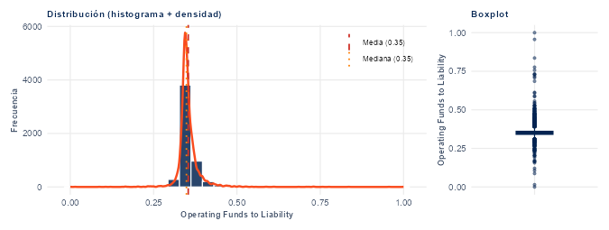

El histograma de Operating Funds to Liability muestra un marcado sesgo a la derecha (asimetría positiva), con una media de 0.3539 ratio y una mediana de 0.3485 ratio. La curtosis observada de 65.46 indica una concentración notable de observaciones alrededor de la zona central, acompañada por la presencia de valores atípicos en las colas. Esta morfología sugiere una alta homogeneidad en el grueso de las empresas analizadas, pero con comportamientos extremos puntuales a monitorear en la etapa de preprocesamiento.

**Inventory/Working Capital**

| Variable | N | Media | DS | Curtosis | Mediana | Mínimo | Máximo | Q1 | Q3 | IQR |
| --- | --- | --- | --- | --- | --- | --- | --- | --- | --- | --- |
| Inventory/Working Capital | 5456 | 0.2772698 | 0.0061768 | 1138.203 | 0.2771763 | 0 | 0.466868 | 0.2770345 | 0.2774301 | 0.0003956 |

Inventory/Working Capital

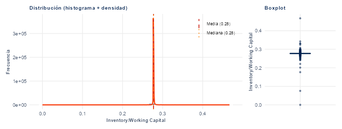

El histograma de Inventory/Working Capital muestra un marcado sesgo a la izquierda (asimetría negativa), con una media de 0.2773 ratio y una mediana de 0.2772 ratio. La curtosis observada de 1139.25 indica una concentración notable de observaciones alrededor de la zona central, acompañada por la presencia de valores atípicos en las colas. Esta morfología sugiere una alta homogeneidad en el grueso de las empresas analizadas, pero con comportamientos extremos puntuales a monitorear en la etapa de preprocesamiento.

**Inventory/Current Liability**

| Variable | N | Media | DS | Curtosis | Mediana | Mínimo | Máximo | Q1 | Q3 | IQR |
| --- | --- | --- | --- | --- | --- | --- | --- | --- | --- | --- |
| Inventory/Current Liability | 5456 | 57918860 | 585595454 | 147.1906 | 0.0064515 | 0 | 9.91e+09 | 0.0031884 | 0.0111107 | 0.0079223 |

Inventory/Current Liability

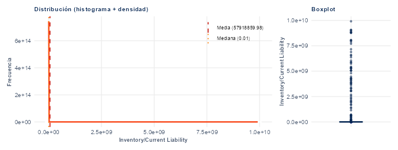

El histograma de Inventory/Current Liability muestra un marcado sesgo a la derecha (asimetría positiva), con una media de 57918859.9798 ratio y una mediana de 0.0065 ratio. La curtosis observada de 147.33 indica una concentración notable de observaciones alrededor de la zona central, acompañada por la presencia de valores atípicos en las colas. Esta morfología sugiere una alta homogeneidad en el grueso de las empresas analizadas, pero con comportamientos extremos puntuales a monitorear en la etapa de preprocesamiento.

**Current Liabilities/Liability**

| Variable | N | Media | DS | Curtosis | Mediana | Mínimo | Máximo | Q1 | Q3 | IQR |
| --- | --- | --- | --- | --- | --- | --- | --- | --- | --- | --- |
| Current Liabilities/Liability | 5456 | 0.7607277 | 0.2073711 | -0.0238045 | 0.8067593 | 0 | 1 | 0.6240874 | 0.9418612 | 0.3177739 |

Current Liabilities/Liability

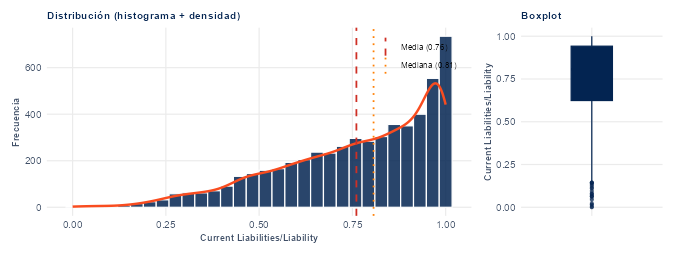

**Working Capital/Equity**

| Variable | N | Media | DS | Curtosis | Mediana | Mínimo | Máximo | Q1 | Q3 | IQR |
| --- | --- | --- | --- | --- | --- | --- | --- | --- | --- | --- |
| Working Capital/Equity | 5456 | 0.7357046 | 0.012269 | 2431.784 | 0.735974 | 0 | 0.9610697 | 0.7335808 | 0.7385325 | 0.0049517 |

Working Capital/Equity

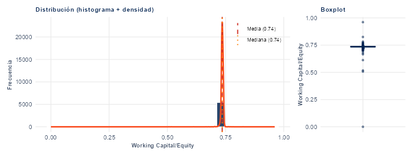

El histograma de Working Capital/Equity muestra un marcado sesgo a la izquierda (asimetría negativa), con una media de 0.7357 ratio y una mediana de 0.7360 ratio. La curtosis observada de 2434.02 indica una concentración notable de observaciones alrededor de la zona central, acompañada por la presencia de valores atípicos en las colas. Esta morfología sugiere una alta homogeneidad en el grueso de las empresas analizadas, pero con comportamientos extremos puntuales a monitorear en la etapa de preprocesamiento.

**Current Liabilities/Equity**

| Variable | N | Media | DS | Curtosis | Mediana | Mínimo | Máximo | Q1 | Q3 | IQR |
| --- | --- | --- | --- | --- | --- | --- | --- | --- | --- | --- |
| Current Liabilities/Equity | 5456 | 0.3314447 | 0.0143355 | 1132.28 | 0.3296675 | 0 | 1 | 0.3280973 | 0.332298 | 0.0042006 |

Current Liabilities/Equity

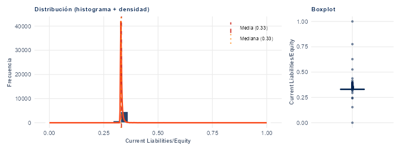

El histograma de Current Liabilities/Equity muestra un marcado sesgo a la derecha (asimetría positiva), con una media de 0.3314 ratio y una mediana de 0.3297 ratio. La curtosis observada de 1133.32 indica una concentración notable de observaciones alrededor de la zona central, acompañada por la presencia de valores atípicos en las colas. Esta morfología sugiere una alta homogeneidad en el grueso de las empresas analizadas, pero con comportamientos extremos puntuales a monitorear en la etapa de preprocesamiento.

**Long-term Liability to Current Assets**

| Variable | N | Media | DS | Curtosis | Mediana | Mínimo | Máximo | Q1 | Q3 | IQR |
| --- | --- | --- | --- | --- | --- | --- | --- | --- | --- | --- |
| Long-term Liability to Current Assets | 5456 | 54330315 | 562094933 | 160.8372 | 0.0020079 | 0 | 9.45e+09 | 0 | 0.0090656 | 0.0090656 |

Long-term Liability to Current Assets

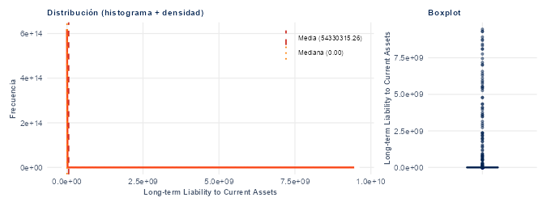

El histograma de Long-term Liability to Current Assets muestra un marcado sesgo a la derecha (asimetría positiva), con una media de 54330315.2566 ratio y una mediana de 0.0020 ratio. La curtosis observada de 160.99 indica una concentración notable de observaciones alrededor de la zona central, acompañada por la presencia de valores atípicos en las colas. Esta morfología sugiere una alta homogeneidad en el grueso de las empresas analizadas, pero con comportamientos extremos puntuales a monitorear en la etapa de preprocesamiento.

**Retained Earnings to Total Assets**

| Variable | N | Media | DS | Curtosis | Mediana | Mínimo | Máximo | Q1 | Q3 | IQR |
| --- | --- | --- | --- | --- | --- | --- | --- | --- | --- | --- |
| Retained Earnings to Total Assets | 5456 | 0.9346148 | 0.0264313 | 328.709 | 0.9376987 | 0 | 0.9966163 | 0.9311217 | 0.9446214 | 0.0134996 |

Retained Earnings to Total Assets

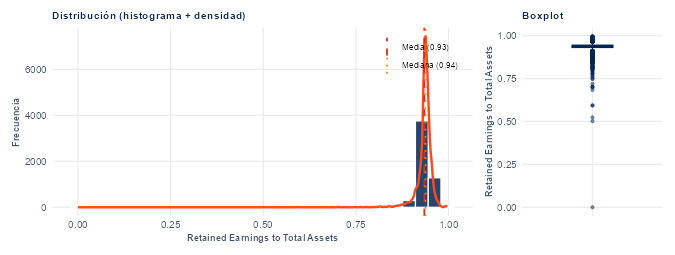

El histograma de Retained Earnings to Total Assets muestra un marcado sesgo a la izquierda (asimetría negativa), con una media de 0.9346 ratio y una mediana de 0.9377 ratio. La curtosis observada de 329.01 indica una concentración notable de observaciones alrededor de la zona central, acompañada por la presencia de valores atípicos en las colas. Esta morfología sugiere una alta homogeneidad en el grueso de las empresas analizadas, pero con comportamientos extremos puntuales a monitorear en la etapa de preprocesamiento.

**Total income/Total expense**

| Variable | N | Media | DS | Curtosis | Mediana | Mínimo | Máximo | Q1 | Q3 | IQR |
| --- | --- | --- | --- | --- | --- | --- | --- | --- | --- | --- |
| Total income/Total expense | 5456 | 0.0023978 | 0.0004722 | 430.1151 | 0.002337 | 0 | 0.0188716 | 0.0022371 | 0.0024907 | 0.0002535 |

Total income/Total expense

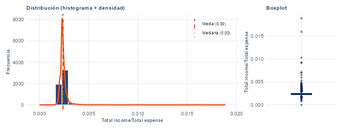

El histograma de Total income/Total expense muestra un marcado sesgo a la derecha (asimetría positiva), con una media de 0.0024 ratio y una mediana de 0.0023 ratio. La curtosis observada de 430.51 indica una concentración notable de observaciones alrededor de la zona central, acompañada por la presencia de valores atípicos en las colas. Esta morfología sugiere una alta homogeneidad en el grueso de las empresas analizadas, pero con comportamientos extremos puntuales a monitorear en la etapa de preprocesamiento.

**Total expense/Assets**

| Variable | N | Media | DS | Curtosis | Mediana | Mínimo | Máximo | Q1 | Q3 | IQR |
| --- | --- | --- | --- | --- | --- | --- | --- | --- | --- | --- |
| Total expense/Assets | 5456 | 0.0293071 | 0.0281681 | 278.3196 | 0.022665 | 0.0008528 | 1 | 0.0145758 | 0.0358409 | 0.021265 |

Total expense/Assets

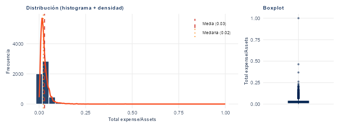

El histograma de Total expense/Assets muestra un marcado sesgo a la derecha (asimetría positiva), con una media de 2.93% y una mediana de 2.27%. La curtosis observada de 278.58 indica una concentración notable de observaciones alrededor de la zona central, acompañada por la presencia de valores atípicos en las colas. Esta morfología sugiere una alta homogeneidad en el grueso de las empresas analizadas, pero con comportamientos extremos puntuales a monitorear en la etapa de preprocesamiento.

**Current Asset Turnover Rate**

| Variable | N | Media | DS | Curtosis | Mediana | Mínimo | Máximo | Q1 | Q3 | IQR |
| --- | --- | --- | --- | --- | --- | --- | --- | --- | --- | --- |
| Current Asset Turnover Rate | 5456 | 1195283187 | 2815659184 | 2.793107 | 0.0001985 | 0 | 1e+10 | 0.0001448 | 0.0004492 | 0.0003044 |

Current Asset Turnover Rate

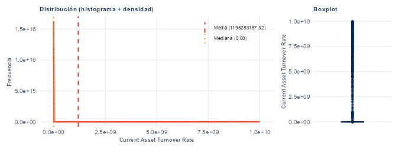

El histograma de Current Asset Turnover Rate muestra un marcado sesgo a la derecha (asimetría positiva), con una media de 1195283187.3171 ratio y una mediana de 0.0002 ratio. La curtosis observada de 2.80 indica una concentración notable de observaciones alrededor de la zona central, acompañada por la presencia de valores atípicos en las colas. Esta morfología sugiere una alta homogeneidad en el grueso de las empresas analizadas, pero con comportamientos extremos puntuales a monitorear en la etapa de preprocesamiento.

**Quick Asset Turnover Rate**

| Variable | N | Media | DS | Curtosis | Mediana | Mínimo | Máximo | Q1 | Q3 | IQR |
| --- | --- | --- | --- | --- | --- | --- | --- | --- | --- | --- |
| Quick Asset Turnover Rate | 5456 | 2150333284 | 3357585702 | -0.3679789 | 0.0002275 | 0 | 9.99e+09 | 0.0001423 | 4862500000 | 4862500000 |

Quick Asset Turnover Rate

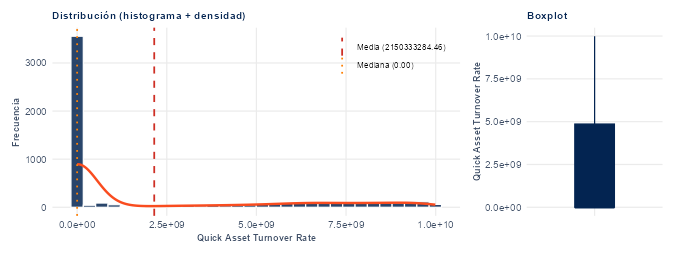

**Working capitcal Turnover Rate**

| Variable | N | Media | DS | Curtosis | Mediana | Mínimo | Máximo | Q1 | Q3 | IQR |
| --- | --- | --- | --- | --- | --- | --- | --- | --- | --- | --- |
| Working capitcal Turnover Rate | 5456 | 0.5939361 | 0.0083723 | 4649.861 | 0.5939621 | 0 | 0.7069782 | 0.593934 | 0.5940024 | 6.83e-05 |

Working capitcal Turnover Rate

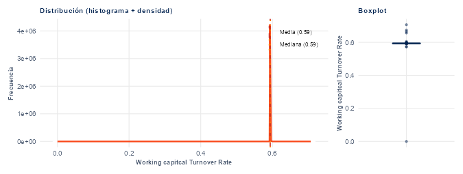

El histograma de Working capitcal Turnover Rate muestra un marcado sesgo a la izquierda (asimetría negativa), con una media de 0.5939 ratio y una mediana de 0.5940 ratio. La curtosis observada de 4654.13 indica una concentración notable de observaciones alrededor de la zona central, acompañada por la presencia de valores atípicos en las colas. Esta morfología sugiere una alta homogeneidad en el grueso de las empresas analizadas, pero con comportamientos extremos puntuales a monitorear en la etapa de preprocesamiento.

**Cash Turnover Rate**

| Variable | N | Media | DS | Curtosis | Mediana | Mínimo | Máximo | Q1 | Q3 | IQR |
| --- | --- | --- | --- | --- | --- | --- | --- | --- | --- | --- |
| Cash Turnover Rate | 5456 | 2465869106 | 2919752742 | -0.3536924 | 1.13e+09 | 1e-04 | 1e+10 | 0.0002831 | 4.475e+09 | 4.475e+09 |

Cash Turnover Rate

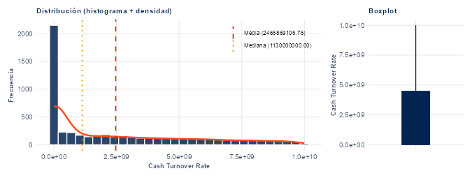

**Cash Flow to Sales**

| Variable | N | Media | DS | Curtosis | Mediana | Mínimo | Máximo | Q1 | Q3 | IQR |
| --- | --- | --- | --- | --- | --- | --- | --- | --- | --- | --- |
| Cash Flow to Sales | 5456 | 0.6714597 | 0.0094483 | 4687.516 | 0.6715738 | 0 | 0.8146757 | 0.6715653 | 0.6715862 | 2.09e-05 |

Cash Flow to Sales

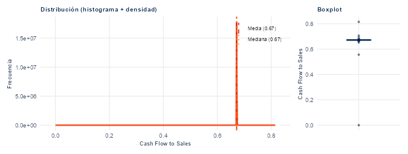

El histograma de Cash Flow to Sales muestra un marcado sesgo a la izquierda (asimetría negativa), con una media de 67.15% y una mediana de 67.16%. La curtosis observada de 4691.82 indica una concentración notable de observaciones alrededor de la zona central, acompañada por la presencia de valores atípicos en las colas. Esta morfología sugiere una alta homogeneidad en el grueso de las empresas analizadas, pero con comportamientos extremos puntuales a monitorear en la etapa de preprocesamiento.

**Fixed Assets to Assets**

| Variable | N | Media | DS | Curtosis | Mediana | Mínimo | Máximo | Q1 | Q3 | IQR |
| --- | --- | --- | --- | --- | --- | --- | --- | --- | --- | --- |
| Fixed Assets to Assets | 5456 | 1524927 | 112638315 | 5451 | 0.1994045 | 0 | 8.32e+09 | 0.0863154 | 0.3780824 | 0.291767 |

Fixed Assets to Assets

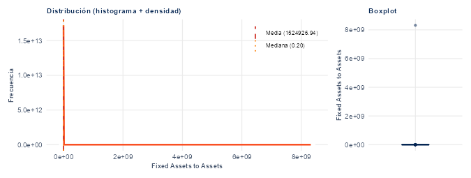

El histograma de Fixed Assets to Assets muestra un marcado sesgo a la derecha (asimetría positiva), con una media de 152492693.81% y una mediana de 19.94%. La curtosis observada de 5456.00 indica una concentración notable de observaciones alrededor de la zona central, acompañada por la presencia de valores atípicos en las colas. Esta morfología sugiere una alta homogeneidad en el grueso de las empresas analizadas, pero con comportamientos extremos puntuales a monitorear en la etapa de preprocesamiento.

**Current Liability to Liability**

| Variable | N | Media | DS | Curtosis | Mediana | Mínimo | Máximo | Q1 | Q3 | IQR |
| --- | --- | --- | --- | --- | --- | --- | --- | --- | --- | --- |
| Current Liability to Liability | 5456 | 0.7607277 | 0.2073711 | -0.0238045 | 0.8067593 | 0 | 1 | 0.6240874 | 0.9418612 | 0.3177739 |

Current Liability to Liability

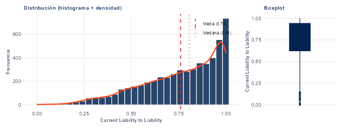

**Current Liability to Equity**

| Variable | N | Media | DS | Curtosis | Mediana | Mínimo | Máximo | Q1 | Q3 | IQR |
| --- | --- | --- | --- | --- | --- | --- | --- | --- | --- | --- |
| Current Liability to Equity | 5456 | 0.3314447 | 0.0143355 | 1132.28 | 0.3296675 | 0 | 1 | 0.3280973 | 0.332298 | 0.0042006 |

Current Liability to Equity

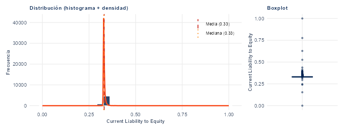

El histograma de Current Liability to Equity muestra un marcado sesgo a la derecha (asimetría positiva), con una media de 0.3314 ratio y una mediana de 0.3297 ratio. La curtosis observada de 1133.32 indica una concentración notable de observaciones alrededor de la zona central, acompañada por la presencia de valores atípicos en las colas. Esta morfología sugiere una alta homogeneidad en el grueso de las empresas analizadas, pero con comportamientos extremos puntuales a monitorear en la etapa de preprocesamiento.

**Equity to Long-term Liability**

| Variable | N | Media | DS | Curtosis | Mediana | Mínimo | Máximo | Q1 | Q3 | IQR |
| --- | --- | --- | --- | --- | --- | --- | --- | --- | --- | --- |
| Equity to Long-term Liability | 5456 | 0.1155609 | 0.0175296 | 1462.303 | 0.1123663 | 0 | 0.922128 | 0.1109332 | 0.117138 | 0.0062048 |

Equity to Long-term Liability

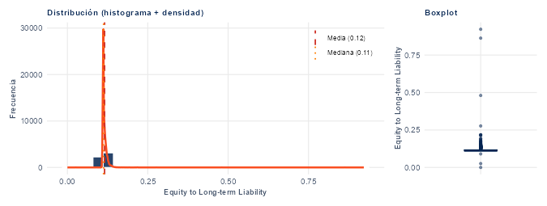

El histograma de Equity to Long-term Liability muestra un marcado sesgo a la derecha (asimetría positiva), con una media de 0.1156 ratio y una mediana de 0.1124 ratio. La curtosis observada de 1463.64 indica una concentración notable de observaciones alrededor de la zona central, acompañada por la presencia de valores atípicos en las colas. Esta morfología sugiere una alta homogeneidad en el grueso de las empresas analizadas, pero con comportamientos extremos puntuales a monitorear en la etapa de preprocesamiento.

**Cash Flow to Total Assets**

| Variable | N | Media | DS | Curtosis | Mediana | Mínimo | Máximo | Q1 | Q3 | IQR |
| --- | --- | --- | --- | --- | --- | --- | --- | --- | --- | --- |
| Cash Flow to Total Assets | 5456 | 0.6494136 | 0.047701 | 18.48362 | 0.6451749 | 0 | 1 | 0.6333341 | 0.6622554 | 0.0289212 |

Cash Flow to Total Assets

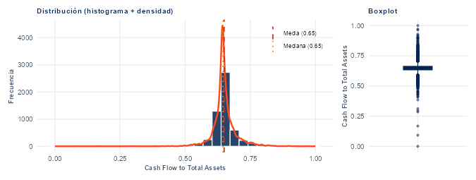

El histograma de Cash Flow to Total Assets muestra una distribución relativamente simétrica, con una media de 0.6494 ratio y una mediana de 0.6452 ratio. La curtosis observada de 18.50 indica una concentración notable de observaciones alrededor de la zona central, acompañada por la presencia de valores atípicos en las colas. Esta morfología sugiere una alta homogeneidad en el grueso de las empresas analizadas, pero con comportamientos extremos puntuales a monitorear en la etapa de preprocesamiento.

**Cash Flow to Liability**

| Variable | N | Media | DS | Curtosis | Mediana | Mínimo | Máximo | Q1 | Q3 | IQR |
| --- | --- | --- | --- | --- | --- | --- | --- | --- | --- | --- |
| Cash Flow to Liability | 5456 | 0.4619436 | 0.0310968 | 83.41974 | 0.4597251 | 0 | 1 | 0.4571469 | 0.4640516 | 0.0069046 |

Cash Flow to Liability

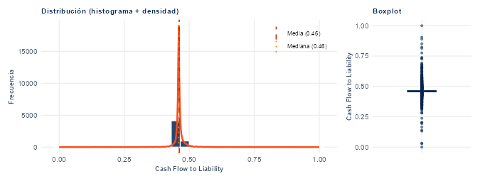

El histograma de Cash Flow to Liability muestra un marcado sesgo a la derecha (asimetría positiva), con una media de 0.4619 ratio y una mediana de 0.4597 ratio. La curtosis observada de 83.50 indica una concentración notable de observaciones alrededor de la zona central, acompañada por la presencia de valores atípicos en las colas. Esta morfología sugiere una alta homogeneidad en el grueso de las empresas analizadas, pero con comportamientos extremos puntuales a monitorear en la etapa de preprocesamiento.

**CFO to Assets**

| Variable | N | Media | DS | Curtosis | Mediana | Mínimo | Máximo | Q1 | Q3 | IQR |
| --- | --- | --- | --- | --- | --- | --- | --- | --- | --- | --- |
| CFO to Assets | 5456 | 0.5933905 | 0.0586501 | 7.459653 | 0.5932241 | 0 | 1 | 0.5657085 | 0.6250784 | 0.0593699 |

CFO to Assets

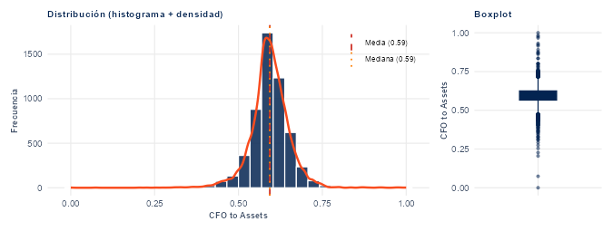

El histograma de CFO to Assets muestra una distribución relativamente simétrica, con una media de 59.34% y una mediana de 59.32%. La curtosis observada de 7.47 indica una concentración notable de observaciones alrededor de la zona central, acompañada por la presencia de valores atípicos en las colas. Esta morfología sugiere una alta homogeneidad en el grueso de las empresas analizadas, pero con comportamientos extremos puntuales a monitorear en la etapa de preprocesamiento.

**Cash Flow to Equity**

| Variable | N | Media | DS | Curtosis | Mediana | Mínimo | Máximo | Q1 | Q3 | IQR |
| --- | --- | --- | --- | --- | --- | --- | --- | --- | --- | --- |
| Cash Flow to Equity | 5456 | 0.3154246 | 0.0105327 | 314.4944 | 0.3149211 | 0 | 0.5692307 | 0.3129953 | 0.3176333 | 0.004638 |

Cash Flow to Equity

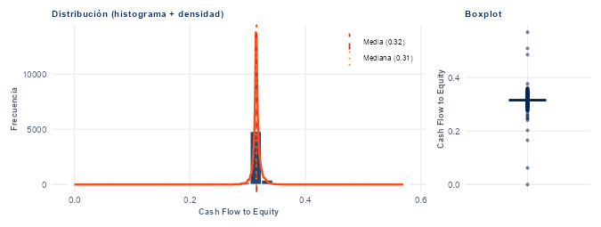

El histograma de Cash Flow to Equity muestra un marcado sesgo a la izquierda (asimetría negativa), con una media de 0.3154 ratio y una mediana de 0.3149 ratio. La curtosis observada de 314.78 indica una concentración notable de observaciones alrededor de la zona central, acompañada por la presencia de valores atípicos en las colas. Esta morfología sugiere una alta homogeneidad en el grueso de las empresas analizadas, pero con comportamientos extremos puntuales a monitorear en la etapa de preprocesamiento.

**Current Liability to Current Assets**

| Variable | N | Media | DS | Curtosis | Mediana | Mínimo | Máximo | Q1 | Q3 | IQR |
| --- | --- | --- | --- | --- | --- | --- | --- | --- | --- | --- |
| Current Liability to Current Assets | 5456 | 0.0315639 | 0.0309875 | 346.0539 | 0.0276725 | 0 | 1 | 0.0181335 | 0.0384918 | 0.0203583 |

Current Liability to Current Assets

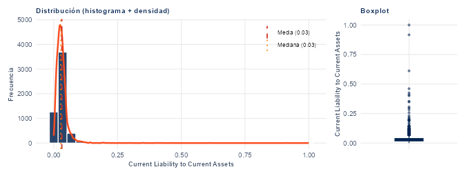

El histograma de Current Liability to Current Assets muestra un marcado sesgo a la derecha (asimetría positiva), con una media de 0.0316 ratio y una mediana de 0.0277 ratio. La curtosis observada de 346.37 indica una concentración notable de observaciones alrededor de la zona central, acompañada por la presencia de valores atípicos en las colas. Esta morfología sugiere una alta homogeneidad en el grueso de las empresas analizadas, pero con comportamientos extremos puntuales a monitorear en la etapa de preprocesamiento.

**Net Income to Total Assets**

| Variable | N | Media | DS | Curtosis | Mediana | Mínimo | Máximo | Q1 | Q3 | IQR |
| --- | --- | --- | --- | --- | --- | --- | --- | --- | --- | --- |
| Net Income to Total Assets | 5456 | 0.807709 | 0.0403029 | 49.67872 | 0.810697 | 0 | 0.9813151 | 0.7968973 | 0.8261512 | 0.0292539 |

Net Income to Total Assets

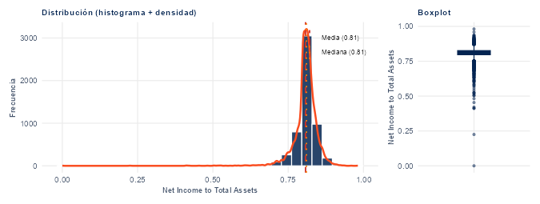

El histograma de Net Income to Total Assets muestra un marcado sesgo a la izquierda (asimetría negativa), con una media de 0.8077 ratio y una mediana de 0.8107 ratio. La curtosis observada de 49.73 indica una concentración notable de observaciones alrededor de la zona central, acompañada por la presencia de valores atípicos en las colas. Esta morfología sugiere una alta homogeneidad en el grueso de las empresas analizadas, pero con comportamientos extremos puntuales a monitorear en la etapa de preprocesamiento.

**Total assets to GNP price**

| Variable | N | Media | DS | Curtosis | Mediana | Mínimo | Máximo | Q1 | Q3 | IQR |
| --- | --- | --- | --- | --- | --- | --- | --- | --- | --- | --- |
| Total assets to GNP price | 5456 | 18266862 | 375077429 | 511.7975 | 0.0020911 | 0 | 9.82e+09 | 0.0009049 | 0.0052807 | 0.0043759 |

Total assets to GNP price

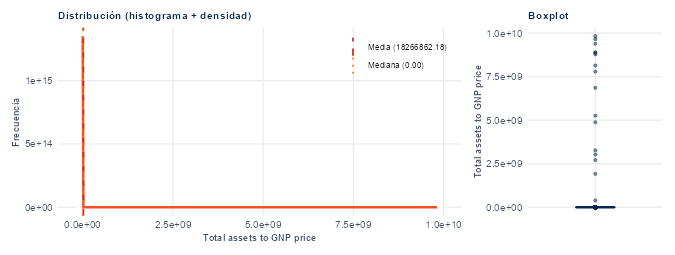

El histograma de Total assets to GNP price muestra un marcado sesgo a la derecha (asimetría positiva), con una media de 18266862.1788 ratio y una mediana de 0.0021 ratio. La curtosis observada de 512.27 indica una concentración notable de observaciones alrededor de la zona central, acompañada por la presencia de valores atípicos en las colas. Esta morfología sugiere una alta homogeneidad en el grueso de las empresas analizadas, pero con comportamientos extremos puntuales a monitorear en la etapa de preprocesamiento.

**No-credit Interval**

| Variable | N | Media | DS | Curtosis | Mediana | Mínimo | Máximo | Q1 | Q3 | IQR |
| --- | --- | --- | --- | --- | --- | --- | --- | --- | --- | --- |
| No-credit Interval | 5456 | 0.6239104 | 0.0096167 | 813.308 | 0.623877 | 0.408682 | 1 | 0.6236342 | 0.6241716 | 0.0005374 |

No-credit Interval

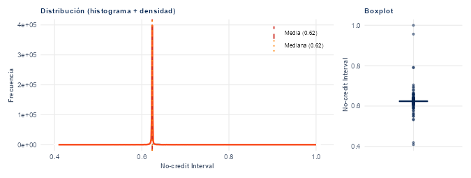

El histograma de No-credit Interval muestra un marcado sesgo a la derecha (asimetría positiva), con una media de 0.6239 días y una mediana de 0.6239 días. La curtosis observada de 814.05 indica una concentración notable de observaciones alrededor de la zona central, acompañada por la presencia de valores atípicos en las colas. Esta morfología sugiere una alta homogeneidad en el grueso de las empresas analizadas, pero con comportamientos extremos puntuales a monitorear en la etapa de preprocesamiento.